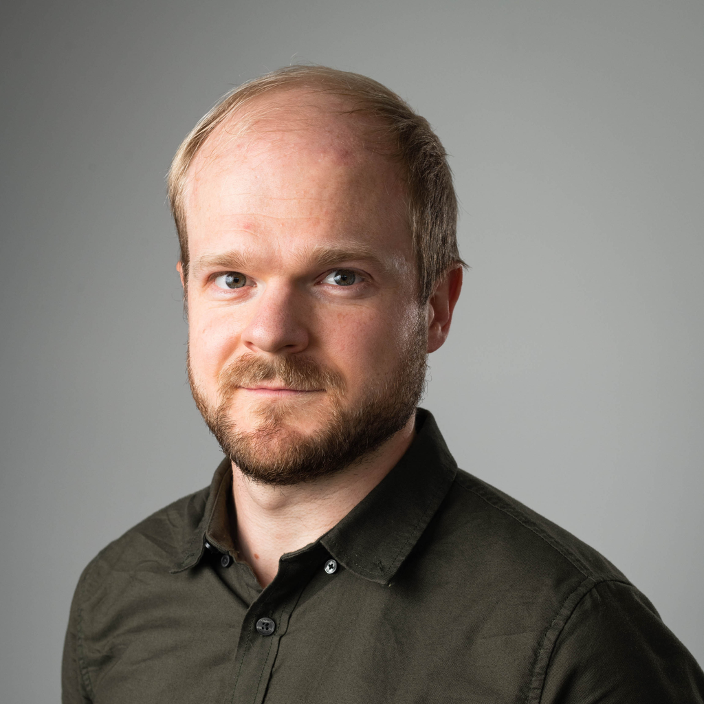

# Nicholas Clifton, PhD, AFHEA

## Bio

My research focuses on studying gene expression patterns of biological pathways associated with psychiatric disorders. I use multi-omics approaches to track expression dynamics across development and apply these data to questions about genetic risk with bioinformatics.

## Research Posts

**[University of Exeter](https://experts.exeter.ac.uk/38790-nicholas-clifton)** Senior Research Fellow, Exeter Medical School | 2022-Present

**[Cardiff University](https://www.cardiff.ac.uk/people/view/105079-clifton-nicholas)** Research Associate, MRC Centre for Neuropsychiatric Genetics and Genomics | 2021-2022

**Cardiff University** Research Fellow, Neuroscience and Mental Health Research Institute | 2018-2021

**Cardiff University** Early Career Research Fellow, Neuroscience and Mental Health Research Institute | 2016-2018

## Selected Publications

- Clifton NE, Lin JQ, Holt CE, O’Donovan MC, Mill J (2024). Enrichment of the Local Synaptic Translatome for Genetic Risk Associated With Schizophrenia and Autism Spectrum Disorder. Biological Psychiatry, https://doi.org/10.1016/j.biopsych.2023.12.006
- Clifton NE, Bosworth ML, Haan N, Rees E, Holmans PA, Wilkinson LS, Isles AR, Collins MO, Hall J (2022). Developmental disruption to the cortical transcriptome and synaptosome in a model of SETD1A loss-of-function. Human Molecular Genetics, https://doi.org/10.1093/hmg/ddac105
- Clifton NE, Collado-Torres L, Burke EE, Pardinas AF, Harwood JC, Di Florio A, Walter JTR, Owen MJ, O’Donovan MC, Weinberger DR, Holmans PA, Jaffe AE, Hall J (2021). Developmental profile of psychiatric risk associated with voltage-gated cation channel activity. Biological Psychiatry, https://doi.org/10.1016/j.biopsych.2021.03.009
- Clifton NE, Rees E, Holmans PA, Pardinas AF, Harwood JC, Di Florio A, Kirov G, Walter JTR, O’Donovan MC, Owen MJ, Hall J, Pocklington, AJ (2020). Genetic association of FMRP targets with psychiatric disorders. Molecular Psychiatry, https://doi.org/10.1038/s41380-020-00912-2.

## Apps and Tools

**[authentiSci](https://chrome.google.com/webstore/detail/authentisci/fdadlapmjbbbgoliolmlpkjknbfocjfk)** | Browser extension allowing scientists to provide feedback on the validity of online science news

**Block the Flock - no longer available on Play Store** | Competitive Android game, built in Unity